# Advanced Vizualisation in R:

Practice

Stepan Polikanov

2022-07-01

# Для сыщиков

Я порыскал по интернету в поисках плохих визуализаций и предлагаю Вам проанализировать их и указать на грешки, грехи и греков(?):

*Пишите ответы здесь, в отдельном файле, или мне в сообщения: полная свобода*

Эти два графика иллюстрируют заболевания COVID-19 в Аризоне в целом (1.1), и заболевания в округе Навахо в частности (1.2) - в чём проблема?

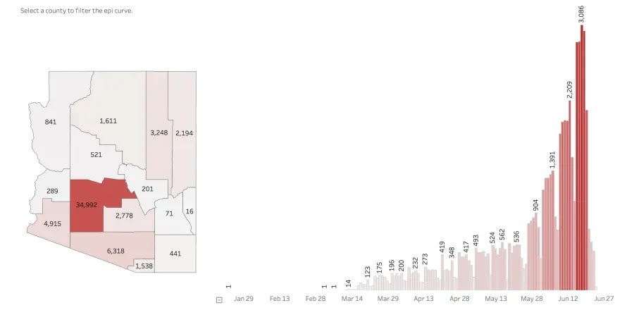

Figure 1.1: *Arizona COVID Infections*

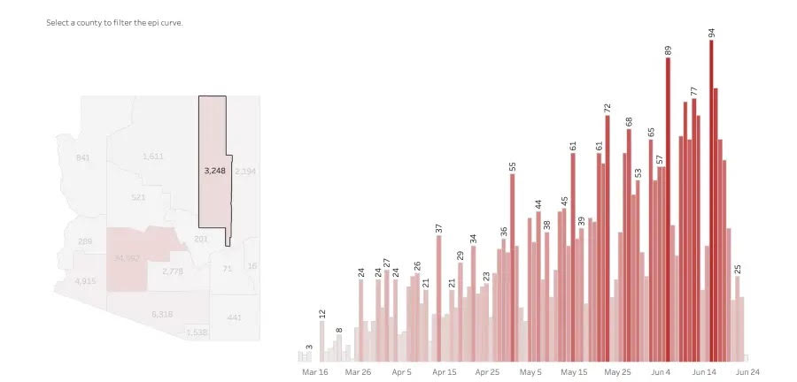

Figure 1.2: *Navajo county COVID Infections*

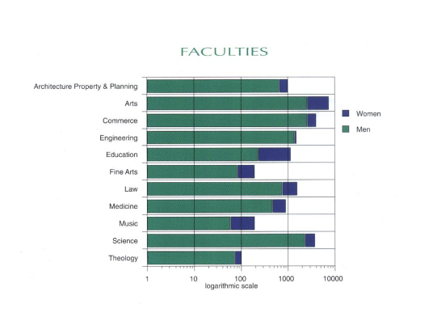

Figure 2: *Faculty size and Gender Distributions*

Этот график показывает распределение инфекций COVID-19 по разным частям Великобритании, и выглядит достаточно безобидным: так ли это?

[figure not shown]

Figure 3: *COVID-19 infections by region of Great Britain*

Наш следующий претендент точно не страдает от минимализма, показывая связь между результатами экзамена ACT и получением гранта Пелла для студентов, которые не могут сами заплатить за колледж. Но что кроется за хорошими цветами?

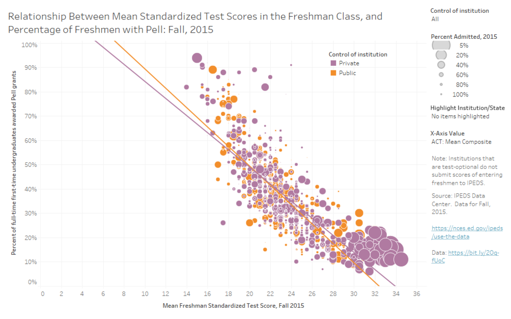

Figure 4: *ACT scores and Pell grant eligibility*

И последний, для самых креативных сыщиков: график показывает издержки (затраты) на колледж против заработка выпускников в Business Insider. По нему был сделан вывод о том, что высшее образование больше ‘не стоит того’, так как затраты на колледж существенно превышают returns в виде зарплат после выпуска.

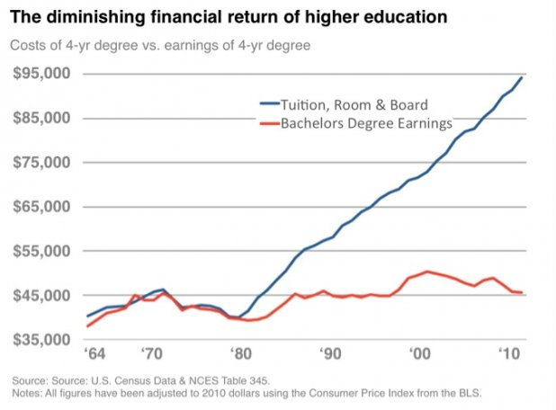

Figure 5: *College Costs vs Returns*

# Для Практиков:

Представляб Вам далее несколько наборов данных и заданий ассоциированных с ними для тренировки ваших **сочных** визуализаций.

_Для чистоты и красоты советую Вам создать отдельный R script, где вы будете этим заниматься, в конце можно скинуть мне для того чтобы я вам месяц не отвечал полезных комментариев.

## Задание I:

Первый датасет - аггрегированные данные по принятию на обучение в университете Беркли, всё довольно стардартно.

```r
# Пакеты которые могут Вам понадобиться:
require(ggplot2)
require(dplyr)
require(ggExtra)
require(ggpubr)
require(ggalt)
require(remotes)
require(ggcorrplot)
require(lubridate)
require(forecast)

install.packages("openintro")
library(openintro)

# Данные для Задания I
data(UCBAdmissions)
UCBAdmissions <- as.data.frame(UCBAdmissions)
```

Создайте (изваяйте, высрите) график, который умело бы отражал распределение принятых на обучение в зависимости от гендера и департамента. График должен быть один, естественно.

## Задание II

Перед Вами знакомый некоторым из Вас датасет hsb2 про тесты студентов из разных школ. Для начала визуализируйте распределение оценок по социальным наукам в зависимости от расы, гендера и социально-экономического положения студентов.

```r
# Данные для Задания II
hsb2
```

## Задание III

Продолжаем рассматривать датасет, теперь посмотрим на корреляцию между оценками тестов по математике, письму и чтению. Включите разбиение результатов по типу школы и программы.

```r
# Данные для Задания III
hsb2
```

## Задание IV

Следующий датасет - про экономичекие показатели США с 1947 до 1963, а задача - построить time series график по двум переменным - количество человек в Вооружённых силах и количеству незанятых (обе переменные представлены в десятках тысяч человек).

*Переменная года трансформирована в формат даты*

```r
# Данные для Задания IV
data(longley)
longley <- longley %>% mutate(Year = as.Date(strptime(Year, "%Y")))
```

## Задание V

Пользуясь позитивным датасетом о смертях на дорогах в Британии 1969-84 постройте сезонный time-series график (обратите внимание, что данные уже в корректном формате).

```r
# Данные для Задания V
data(UKDriverDeaths)
```